# Wine Quality Exploration

### 绘图二

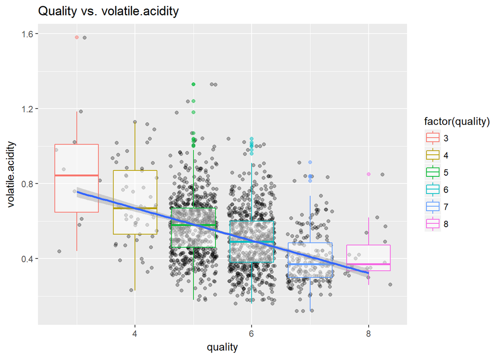

### 描述二

##### 质量与游离酸度成明显负相关，游离酸度越高，其质量评分越低。

### 绘图三

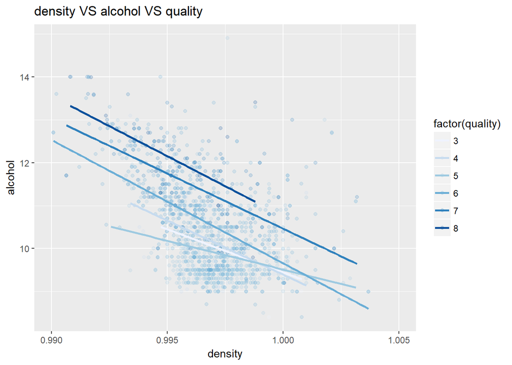

### 描述三

##### 不同质量下，density和alcohol呈负相关，相关系数-0.5

# 反思

#### 对于葡萄酒，个人不是很了解，不像钻石那样，大家都知道越重越漂亮的越贵，所以对于葡萄酒质量影响因素的分析，只能挨个全部分析，对于单变量的分析，有的变量存在异常值，无法判断其是否错误，或者只是反常而已，因此只能舍弃，另外由于要取不同的组宽，不方便用循环进行，因此无奈的做了大量重复工作。

#### 对于双变量分析，我个人不喜欢酒，只喜欢奶茶奶糖等，对于红酒，我觉得微酸，较甜，不苦是比较好的，可品酒师显然不这么认为，所以只能继续挨个探索，最终发现质量与游离酸度及酒精度有明显关系，而游离酸度又与柠檬酸明显相关，酒精度和密度明显相关，综上，质量可能与游离酸度,柠檬酸，酒精度，及密度相关。另外发现，固定酸度和PH相关性是0.683，算是强相关。

#### 对与多变量分析，主要探索不同质量等级下其它强相关变量的相关度变化，发现酒精与PH在不同质量下的相关度变化较大。最后此数据集由于数据量略小，分析得出结论的过程不是很明显，另外变量都是数值型，没有分类变量，在多变量分析时数据略显得鸡肋。

#### 对于此数据集，还可进一步探索存在异常值的变量在消除异常值或对变量进行对数转换后，再进行双变量和多变量的分析。